# delivery stats

Danielle Janney

4/4/2021

# My Delivery Order Stats

This data is personal and likely not much use for anyone else. I work part-time as a restaurant delivery driver and for fourteen days I collected information for each delivery I took. There are 182 entries that look like this:

```
##       Date Day_of_the_Week   Tip Order_Total Payment_Type
## 1 03_09_21         Tuesday 10.00       75.02           CC
## 2 03_09_21         Tuesday    NA       58.58         Cash
## 3 03_09_21         Tuesday  5.32       37.40         Acct
## 4 03_09_21         Tuesday  4.19       37.08           CC
## 5 03_09_21         Tuesday 14.08      117.53           CC
## 6 03_09_21         Tuesday  4.98       34.64           CC
```

## What am I doing with this data?

I am interested to see how the variables of payment type and order total impact the tip I recieve. Looking at the table above, there are three payment types: Acct (third-party delivery accounts: UberEats, BiteSquad, and GrubHub), Cash, and CC (credit card). I did not document any cash tips, but kept record of cash orders regardless.

## Scatter Plots

The first scatter plot shows the relationship between tips and order totals (which include the tip)

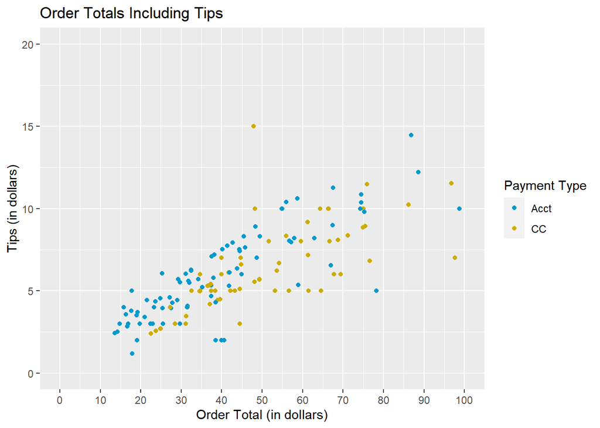

It is difficult to produce an accurate subtotal for the orders for a couple of reasons:  
1. Some orders have no delivery fee as a promotion  
2. Acct orders have different delivery fees and are not discerned  
I will instead simply compare the order’s total (before tip) to the order’s tip:

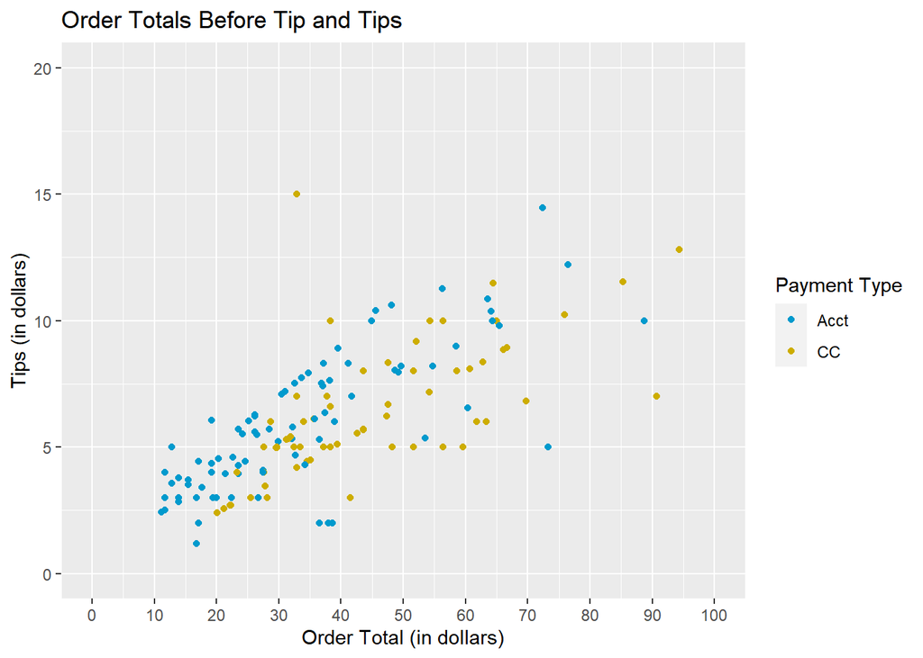

A very subtle difference, I must say.

## A Boxplot

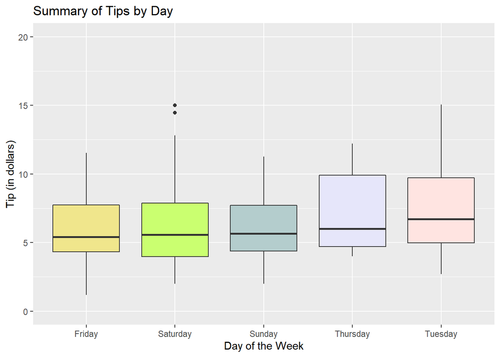

To be continued…